# Initial_exploration_on_patient_location_data

Skylar Zeng

2025-07-21

# Purpose

The purpose of this notebook is to tabulate and visualize patiend and location data of interest for the UM Sys Bio C diff data. They are:

1. Descriptive statistice: patient data (age, gender, race, LOS)
2. hospital vs. community onset of infection by MLST
3. for inpatient infections, days between admission and infection onset by MLST
4. Locations variation and temporal overlap

# Demographics (n=727)

## Age distribution (at least 18 yrs-old)

**Interpretation:** Strong skew toward older adults. This pattern is consistent with the known epidemiology of C. difficile, where older individuals — particularly those over 65 — are at increased risk due to more frequent healthcare exposure, antibiotic use, and comorbidities.

```
##    Min. 1st Qu.  Median    Mean 3rd Qu.    Max.
##   18.00   47.00   61.00   58.07   71.00  102.00
```

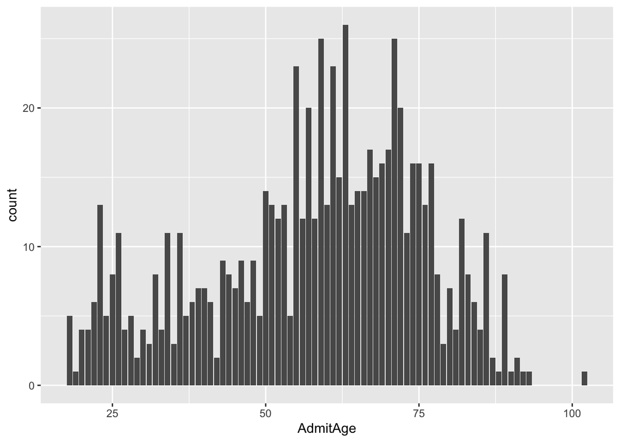

## Gender

```
##
##   F   M
## 366 361
```

## Race

**Interpretation:** The dataset is overwhelmingly composed of Caucasian patients, who represent 84.4% (610/723) of the total. African American patients make up the second-largest group at 10.9% (79). All other racial groups are represented in small numbers

```
##
##                 African American American Indian or Alaska Native
##                               79                                4
##                            Asian                        Caucasian
##                               10                              610
##                            Other                          Unknown
##                               19                                1
```

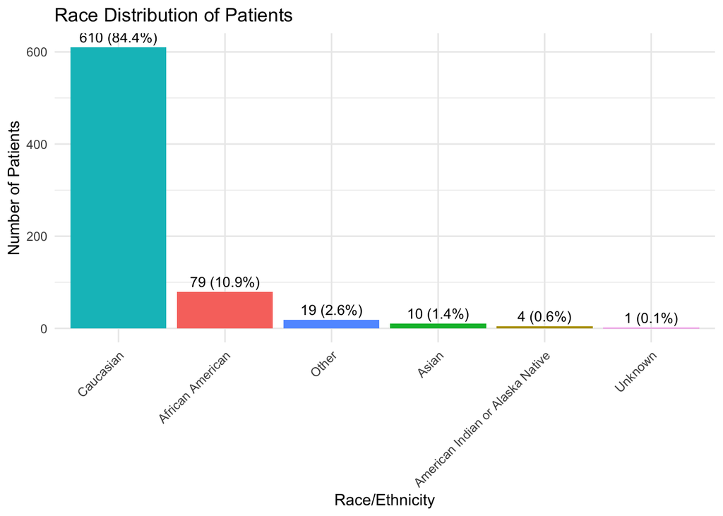

## Length of stay (days) **Interpretation:** - The peak in frequency occurs within the first 5 days, indicating that short stays are most common. - Median LOS is 8 days, with an interquartile range (IQR) from 5 to 18 days. - Several patients had very prolonged hospitalizations, including stays over 100 days, and a maximum LOS of 350 days.

```
##    Min. 1st Qu.  Median    Mean 3rd Qu.    Max.
##     0.0     5.0     8.0    14.1    18.0   350.0
```

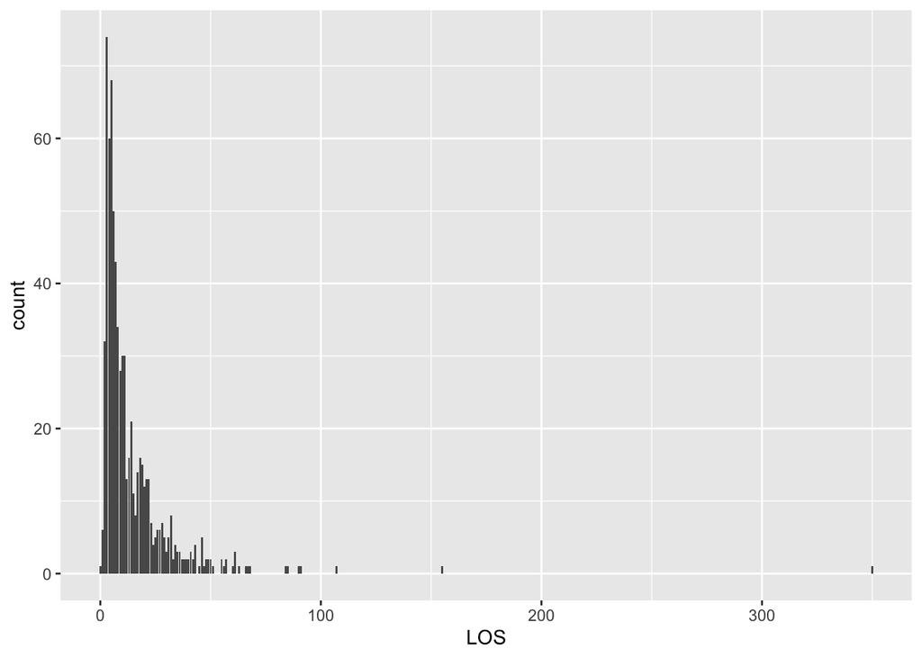

## Infection Onset Type (0 = Community-Onset, 1 = Hospital-Onset)

```
##
##   0   1
## 410 317
```

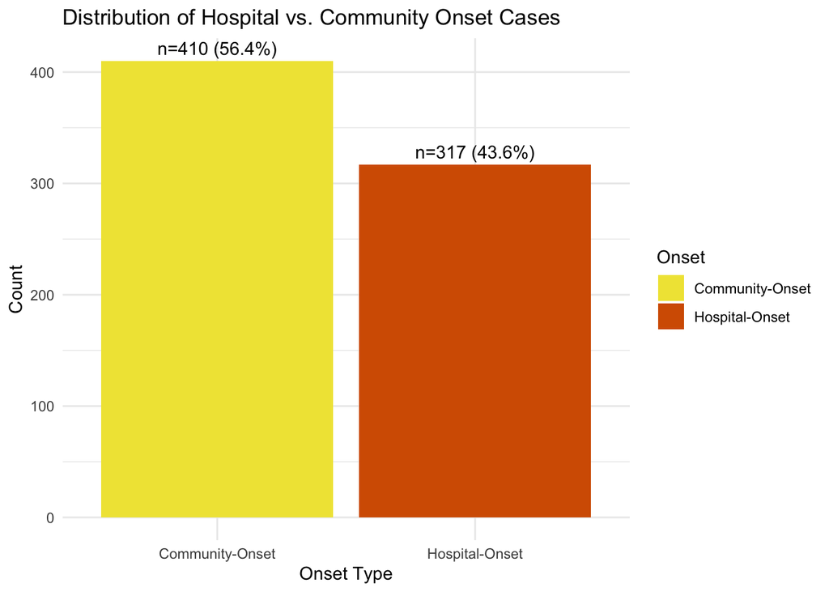

## Inpatients vs. Outpatient (1 == inpatient)

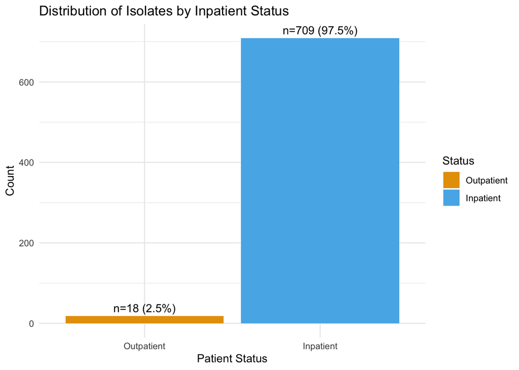

## ST type

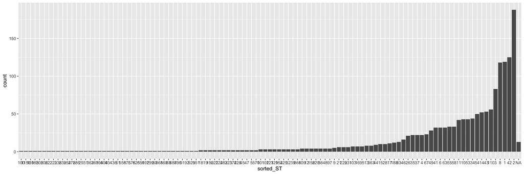

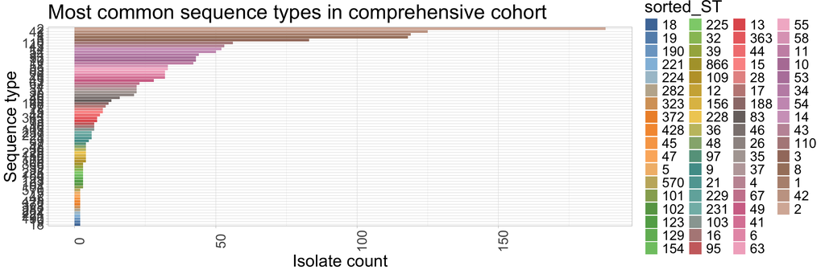

```
##
##    0    1
## 1326  264
```

Repeat above plot with secondary isolates highlighted

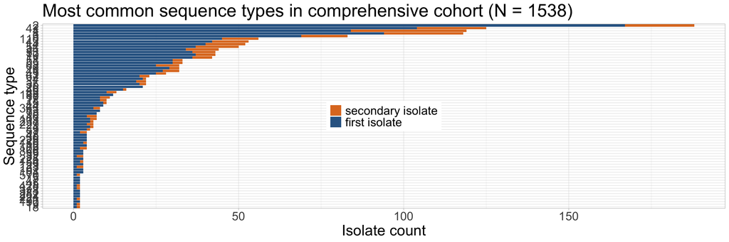

## ST on HO vs. CO

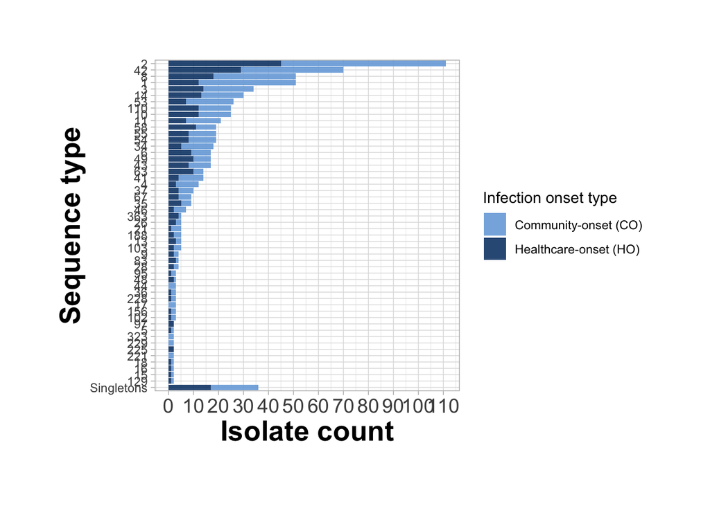

For the rest of the plots/tables, I will only keep specific bins for ST types for which we have more than 50 isolates. The rest will get grouped in an “other” bin, along with the novel and non-determined sequence types according to Ariba.

Next I took the most common sequence types and broke down those counts by inpatient vs. not (again inpatient == 1)

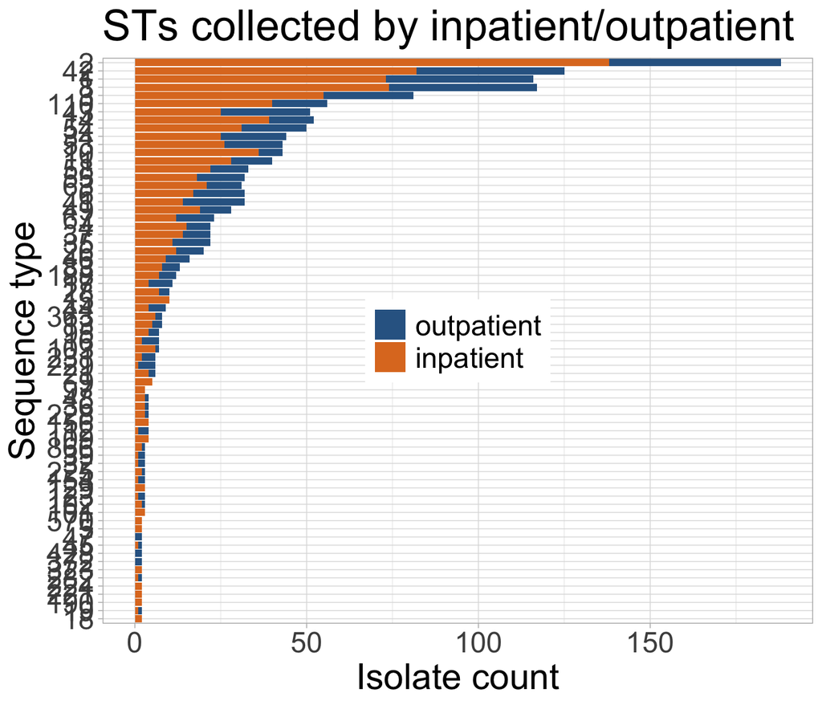

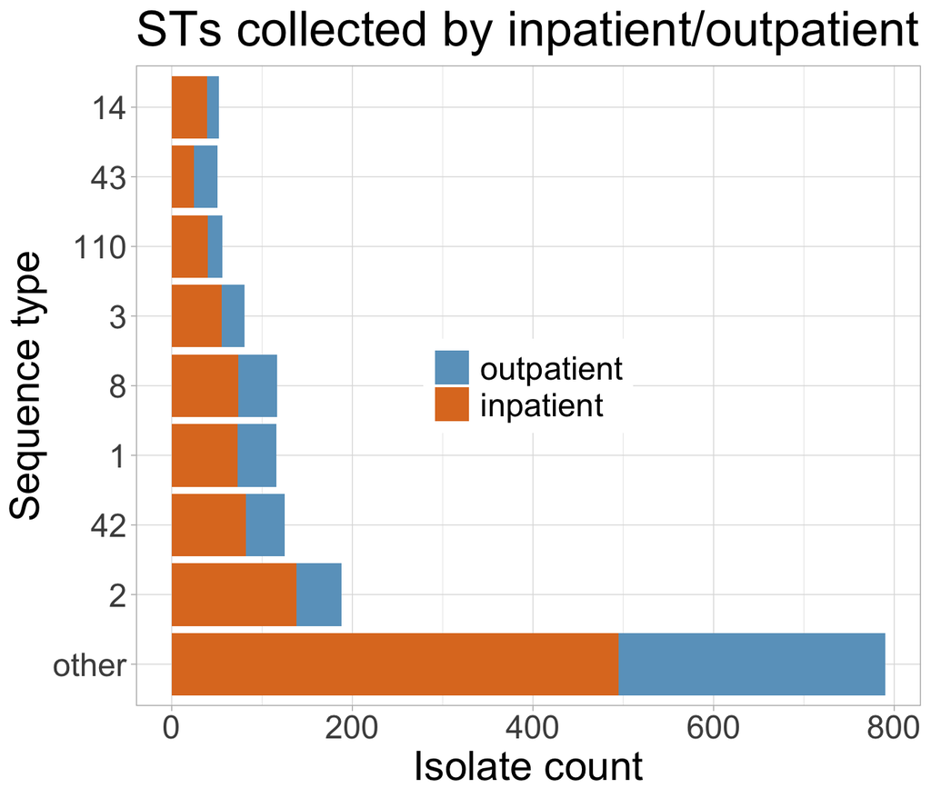

And then hospital-onset vs. not

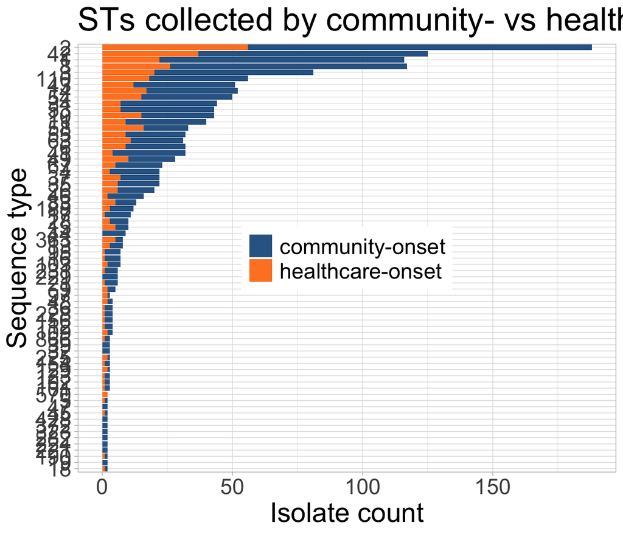

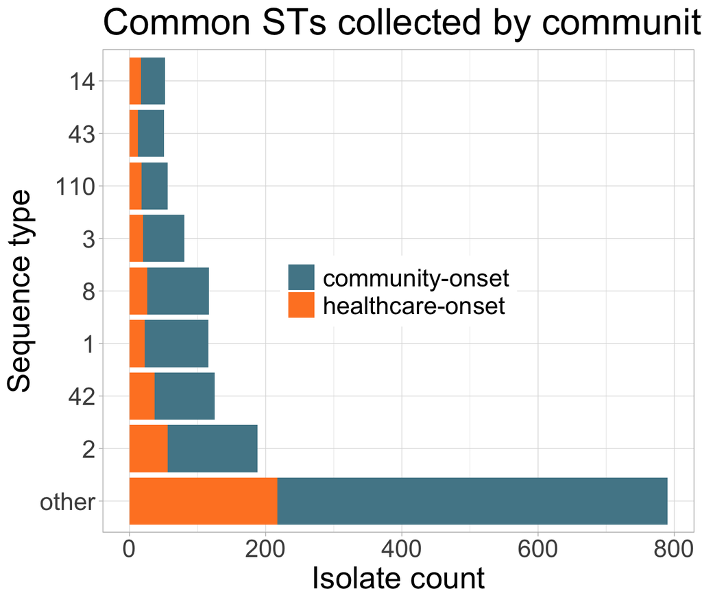

Next I looked at days until infection onset by sequence type for those isolates that were collected from inpatients (note does not restrict to hospital-onset only)

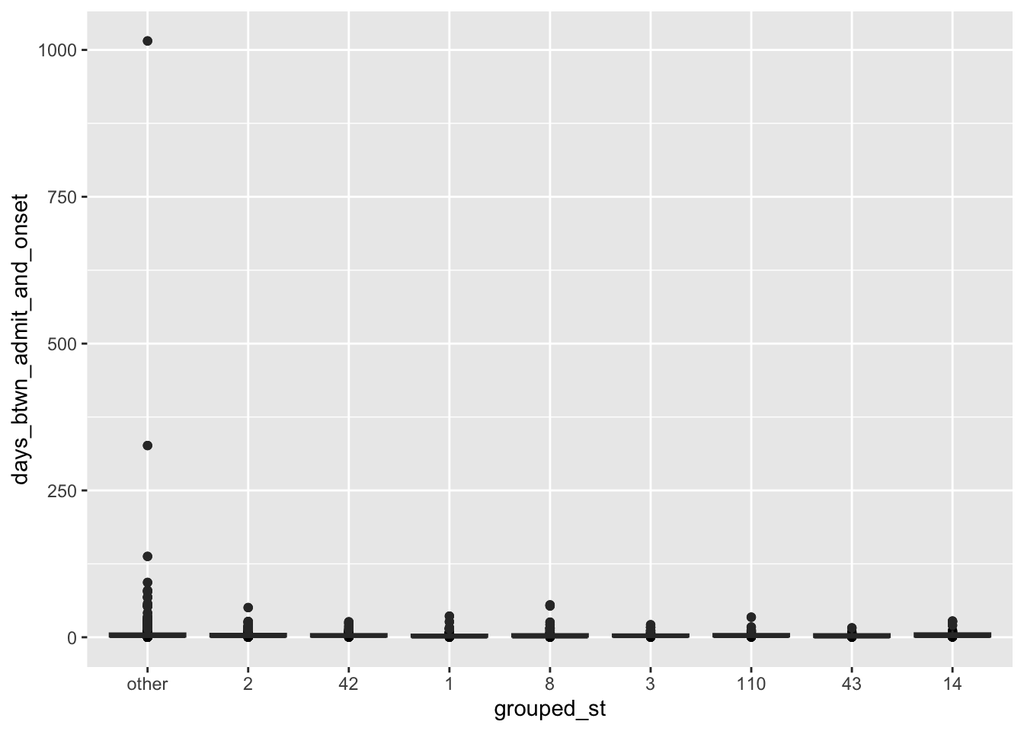

The raw data has outliers that make it hard to visualize. Removing those:

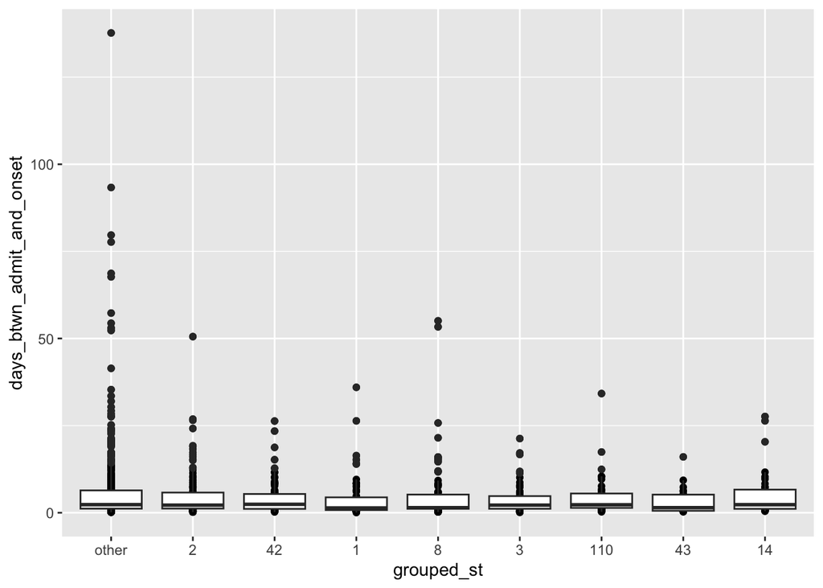

Still pretty scrunched at the bottom. Let’s look at a table instead:

| grouped_st | median | mean | sd |
| --- | --- | --- | --- |
| other | 2.320833 | 8.784634 | 49.059500 |
| 2 | 2.176042 | 4.819007 | 6.716353 |
| 42 | 2.414931 | 4.235010 | 4.963369 |
| 1 | 1.376389 | 3.903843 | 5.998555 |
| 8 | 1.447917 | 5.224456 | 9.708987 |
| 3 | 2.176389 | 3.867525 | 4.569372 |
| 110 | 2.279167 | 4.601510 | 6.122792 |
| 43 | 1.452083 | 3.521222 | 3.731243 |
| 14 | 2.311806 | 5.137447 | 6.564452 |

## plot timing and recurrence

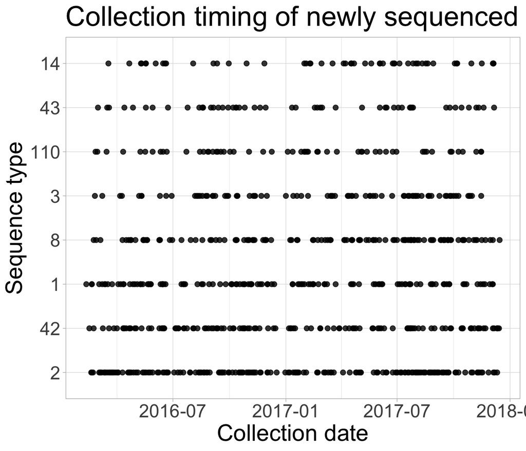

## Summary Table

|  | Overall (N=727) |
| --- | --- |
| Age |  |
| Mean (SD) | 58.1 (17.6) |
| Median [Min, Max] | 61.0 [18.0, 102] |
| BMI |  |
| Mean (SD) | 27.5 (7.53) |
| Median [Min, Max] | 26.3 [12.4, 73.5] |
| Missing | 18 (2.5%) |
| Admission Type |  |
| Emergency | 484 (66.6%) |
| Scheduled | 117 (16.1%) |
| Urgent | 126 (17.3%) |
| Sex |  |
| Female | 366 (50.3%) |
| Male | 361 (49.7%) |
| Race |  |
| African American | 79 (10.9%) |
| American Indian or Alaska Native | 4 (0.6%) |
| Asian | 10 (1.4%) |
| Caucasian | 610 (83.9%) |
| Other | 19 (2.6%) |
| Unknown | 1 (0.1%) |
| Missing | 4 (0.6%) |
| Length of Stay (days) |  |
| Mean (SD) | 14.1 (19.4) |
| Median [Min, Max] | 8.00 [0, 350] |
| Patient Status |  |
| Outpatient | 18 (2.5%) |
| Inpatient | 709 (97.5%) |
| Onset Type |  |
| Community | 410 (56.4%) |
| Hospital | 317 (43.6%) |

# Initial exploration of locations and linkages

## Locations distribution

```
## # A tibble: 1 × 1
##   unique_patients
##             <int>
## 1            1020
```

```
## # A tibble: 86 × 2
##    Unit  n_patients
##    <chr>      <int>
##  1 ESA          788
##  2 OR           322
##  3 DVU          314
##  4 MPUA         250
##  5 6B1          238
##  6 5B1          233
##  7 8B2          204
##  8 UADM         174
##  9 7B           171
## 10 6D           166
## # ℹ 76 more rows
```

## Overall Overlaps

```
##    FacilityCode n_pairs
##          <char>   <int>
## 1:          UUH   71605
## 2:          UMH     863
## 3:         UCVC     176
## 4:          UVH       1
```

```
##     FacilityCode   Unit n_pairs
##           <char> <char>   <int>
##  1:          UMH   FADM     111
##  2:          UUH     OR     511
##  3:          UUH    ESA    2499
##  4:          UMH     8E       7
##  5:          UUH     5A       7
##  6:          UUH     5C      27
##  7:         UCVC    ORC      26
##  8:          UUH   UADM     226
##  9:          UUH    8A3      36
## 10:          UUH     5D      13
## 11:          UUH     8C       6
## 12:         UCVC   CVC4       6
## 13:          UUH     6A      10
```

[output cut: 21 more lines]

```
##    FacilityCode   Unit   Room n_pairs
##          <char> <char> <char>   <int>
## 1:          UUH     OR   UHOR     481
## 2:         UCVC    ORC   CVOR      25
## 3:          UUH     8C   8441       1
## 4:         UCVC   CATH   CATH       1
## 5:          UMH   MHOR   MHOR       1
## 6:          UUH     8C   8141       1
## 7:          UUH     4C   4449       1
## 8:          UUH   AMOU   1126       1
## 9:          UMH    7W1    736       1
```

## Overlap with same ST

```
##    FacilityCode n_pairs
##          <char>   <int>
## 1:          UUH    3254
## 2:          UMH      39
## 3:         UCVC      10
```

```
##     FacilityCode   Unit n_pairs
##           <char> <char>   <int>
##  1:          UUH    ESA     129
##  2:          UUH     OR      24
##  3:          UMH     8E       1
##  4:          UUH   UADM      14
##  5:         UCVC    ORC       1
##  6:          UMH   FADM       3
##  7:          UMH    7W1       9
##  8:          UUH    8A3       1
##  9:          UUH     6A       1
## 10:          UUH     5A       2
## 11:          UUH     6C       1
## 12:         UCVC   CVC4       1
## 13:          UUH     4C       1
## 14:          UUH     6D       1
## 15:          UUH    8B2       1
```

```
##    FacilityCode   Unit   Room n_pairs
##          <char> <char> <char>   <int>
## 1:          UUH     OR   UHOR      22
## 2:         UCVC    ORC   CVOR       1
```